# Exercise 7 – Evaluation III

[Introduction to Machine Learning](https://slds-lmu.github.io/i2ml/)

## Exercise 1: ROC metrics

**Learning goals**

TBD

Consider a binary classification algorithm that yielded the following results on 10 observations. The table shows true classes and predicted probabilities for class 1:

| ID | True class | Prediction |
| --- | --- | --- |
| 1 | 0 | 0.33 |
| 2 | 0 | 0.27 |
| 3 | 0 | 0.11 |
| 4 | 1 | 0.38 |
| 5 | 1 | 0.17 |
| 6 | 1 | 0.63 |
| 7 | 1 | 0.62 |
| 8 | 1 | 0.33 |
| 9 | 0 | 0.15 |
| 10 | 0 | 0.57 |

1. Create a confusion matrix assuming a threshold of 0.5. Point out which values correspond to true positives (`TP`), true negatives (`TN`), false positives (`FP`), and false negatives (`FN`).

**Solution**

First, sort the table:

| ID | True class | Score | Predicted class |
| --- | --- | --- | --- |
| 6 | 1 | 0.63 | 1 |
| 7 | 1 | 0.62 | 1 |
| 10 | 0 | 0.57 | 1 |
| —- | ———— | ——- | —————– |
| 4 | 1 | 0.38 | 0 |
| 1 | 0 | 0.33 | 0 |
| 8 | 1 | 0.33 | 0 |
| 2 | 0 | 0.27 | 0 |
| 5 | 1 | 0.17 | 0 |
| 9 | 0 | 0.15 | 0 |
| 3 | 0 | 0.11 | 0 |

This translates to:

|  | True 1 | True 0 |
| --- | --- | --- |
| Predicted 1 | 2 | 1 |
| Predicted 0 | 3 | 4 |

So we get:

|  | #FN | #FP | #TN | #TP |
| --- | --- | --- | --- | --- |
|  | 3 | 1 | 4 | 2 |

2. Calculate: PPV, NPV, TPR, FPR, ACC, MCE and $F1$ measure.

**Solution**

$$\rho_{\text{PPV}} = \frac{\# \text{TP}}{\# \text{TP}+ \# \text{FP}} =\frac{2}{3}$$

$$\rho_{\text{NPV}} = \frac{\# \text{TN}}{\# \text{TN}+ \# \text{FN}} =\frac{4}{7}$$

$$\rho_{\text{TPR}} = \frac{\# \text{TP}}{\# \text{TP}+ \# \text{FN}} =\frac{2}{5}$$

$$\rho_{\text{FPR}} = \frac{\# \text{FP}}{\# \text{TN}+ \# \text{FP}} =\frac{1}{5}$$

$$\rho_{\text{ACC}} = \frac{\# \text{TP}+ \# \text{TN}}{\# \text{TP}+ \# \text{TN}+
\# \text{FP}+ \# \text{FN}} =\frac{6}{10}$$

$$\rho_{\text{MCE}} = \frac{\# \text{FP}+ \# \text{FN}}{\# \text{TP}+ \# \text{TN}+
\# \text{FP}+ \# \text{FN}} =\frac{4}{10}$$

$$\rho_{F1} = \frac{2\cdot \rho_{\text{PPV}} \cdot \rho_{\text{TPR}}}{
\rho_{\text{PPV}} + \rho_{\text{TPR}}} = 0.5$$

3. Draw the ROC curve and interpret it. Feel free to use `R` or ‘Python’ for the drawing.

**Solution**

**R**

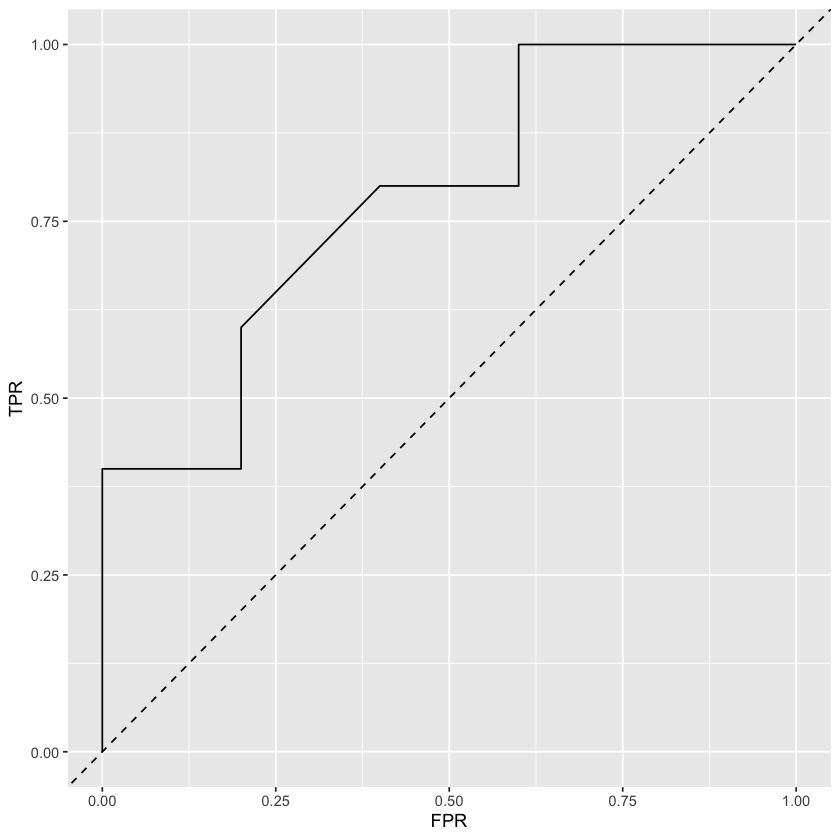

```r
roc_data <- data.frame(
  TPR = c(0, 0.2, 0.4, 0.4, 0.6, 0.8, 0.8, 1, 1, 1),
  FPR = c(0, 0, 0, 0.2, 0.2, 0.4, 0.6, 0.6, 0.8, 1))

ggplot(roc_data, aes(x = FPR, y = TPR)) + geom_line() +
  geom_abline(slope = 1, intercept = 0, linetype = 'dashed')
```

**Python**

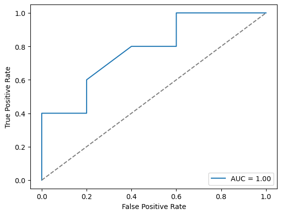

```python
y = np.array([0, 0, 0, 1, 1, 1, 1, 1, 0, 0])
scores = np.array([0.33, 0.27, 0.11, 0.38, 0.17, 0.63, 0.62, 0.33, 0.15, 0.57])
fpr, tpr, thresholds = metrics.roc_curve(y, scores)
roc_display = metrics.RocCurveDisplay(fpr=fpr, tpr=tpr, roc_auc=True).plot()
plt.plot([0, 1], [0, 1], color='grey', linestyle='--')
plt.show()
```

We see that the resulting ROC curve is distinct from the diagonal marking a purely random classifier, but also not too great. The step function character is clearly visible for so few observations (the non-axis-parallel part in the middle is due to the fact that we have two observations with the same score but different true class, so both TPR and FPR go up when we move from $c = 0.35$ to $c= 0.3$).

4. Calculate the AUC.

**Solution**

We can compute the AUC by adding rectangular and triangular areas, s.t.
$$\rho_{\text{AUC}} = 0.2 \cdot 0.4 + 0.2 \cdot 0.6 + \tfrac{1}{2} \cdot
0.2 \cdot 0.2 + 0.2 \cdot 0.8 + 0.4 \cdot 1 = 0.78.$$

5. How would the ROC curve change if you had chosen a different threshold in a)?

**Solution**

Not at all, because the ROC curve is drawn by iterating through *all* thresholds, and the corresponding AUC does not depend on a particular choice of $c$.

## Exercise 2: $k$-NN

**Learning goals**

TBD

Let the two-dimensional feature vectors in the following figure be instances of two different classes (triangles and circles). Classify the point (7, 6) – represented by a square in the picture – with a $k$-NN classifier using $L1$ norm (Manhattan distance):

$$d_\text{Manhattan}(\mathbf{x}, \tilde{\mathbf{x}}) = \sum\limits_{j=1}^p|x_j - \tilde{x}_j|.$$

As a decision rule, use the unweighted number of the individual classes in the $k$-neighborhood, i.e., assign the point to the class that represents most neighbors.

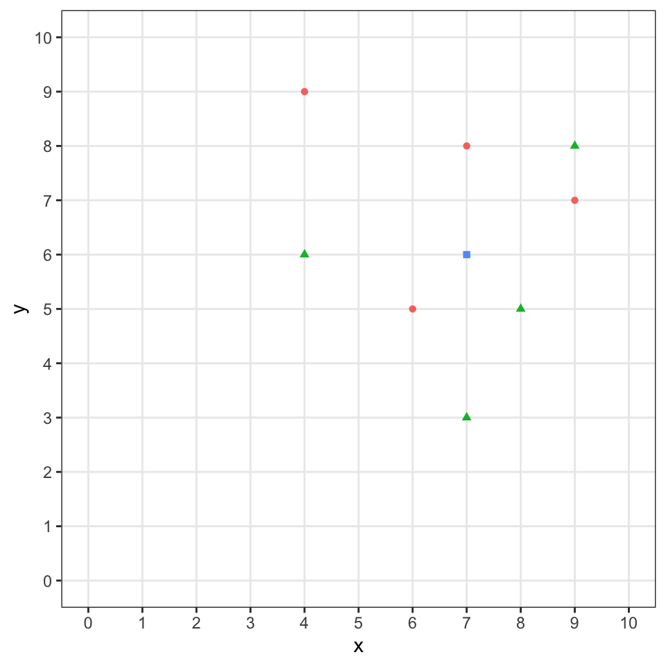

1. $k = 3$

**Solution**

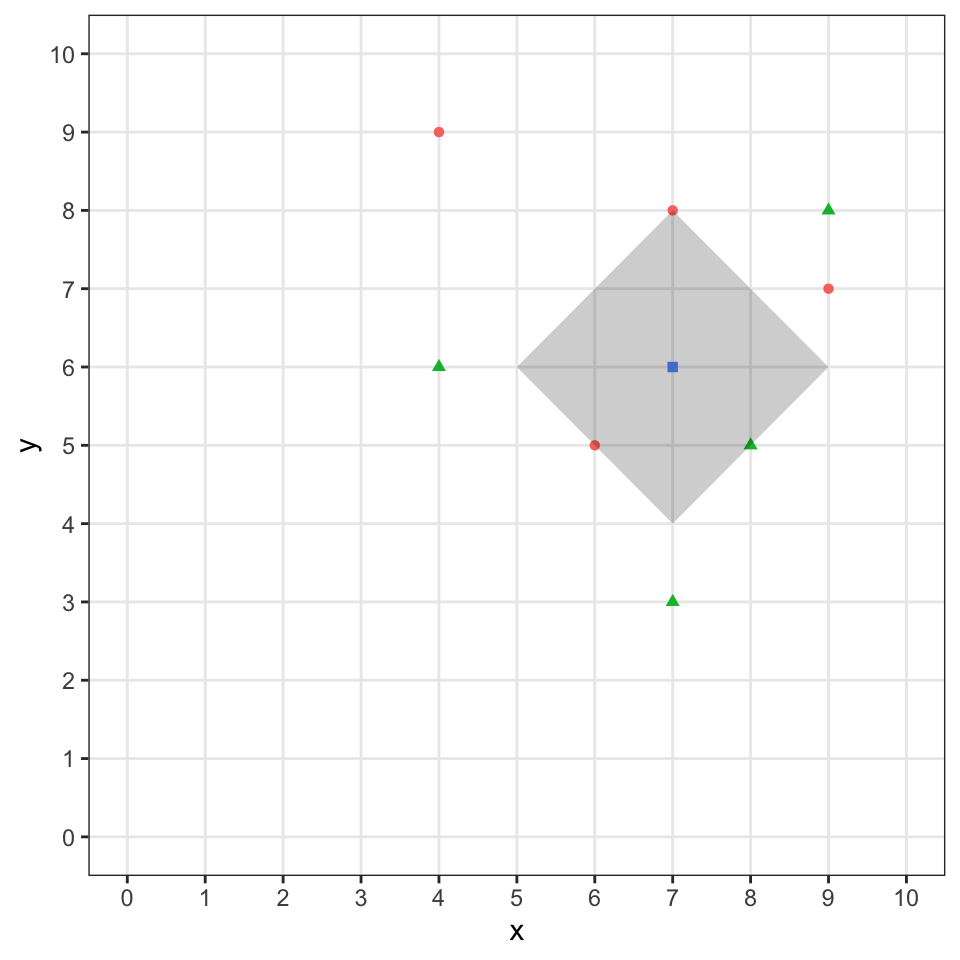

$\Longrightarrow$ 2 circles and 1 triangle, so we predict “circle”:

2. $k = 5$

**Solution**

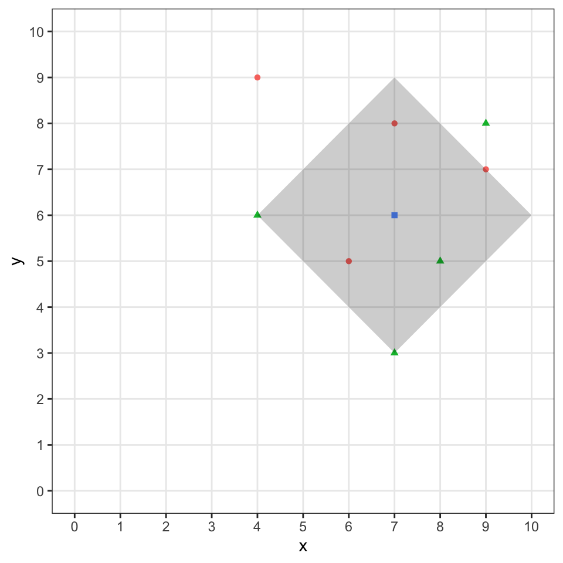

$\Longrightarrow$ 3 circles and 3 triangles, we have to specify beforehand what to do in case of a tie.

3. $k = 7$

**Solution**

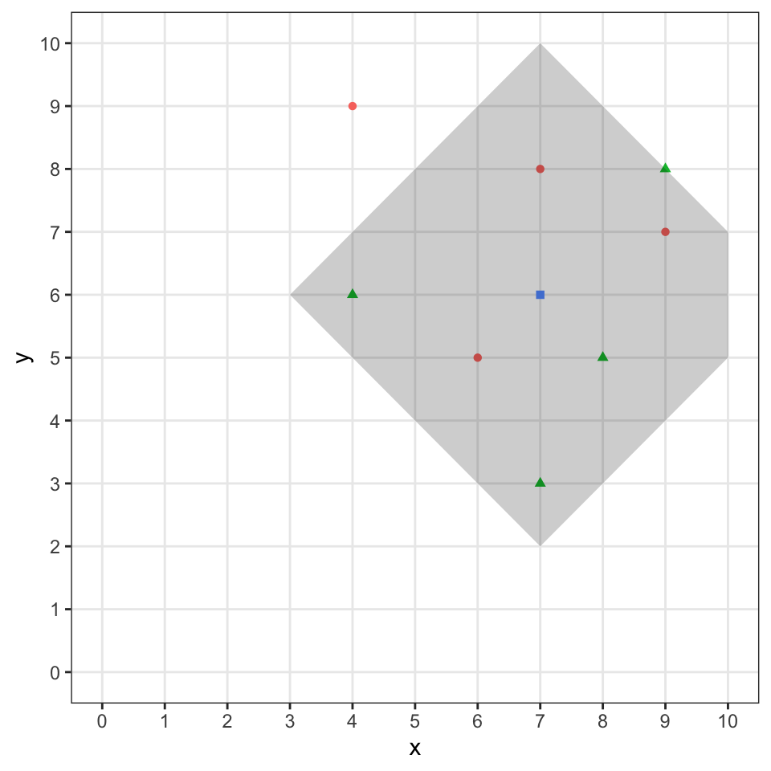

$\Longrightarrow$ 3 circles and 4 triangles, so we predict “triangle”.

Now consider the same constellation but assume a regression problem this time, where the circle-shaped points have a target value of 2 and the triangles have a value of 4.

**Hint**

We now consider both *unweighted* and *weighted* predictions. Recall that weights are computed based on the distance between the point of interest and its respective neighbors. With the Manhattan, or “city block” metric, the distance can be read from the plot by walking along the grid lines (shortest way). For example, in the 3-neighborhood, all points have a distance of 2 from our square, so all get weights $\tfrac{1}{2}$.

1. $k = 3$

**Solution**

$$\hat{y} = \frac{2 + 2 + 4}{3} = \frac{8}{3} \approx 2.67$$

$$\hat{y}_\mathrm{weighted} = \frac{\frac{1}{2}\cdot 2 + \frac{1}{2}\cdot 2 + \frac{1}{2}\cdot 4}{\frac{3}{2}} = \frac{8}{3} \approx 2.67$$

2. $k = 5$

**Solution**

$$\hat{y} = \frac{3 \cdot 2 + 3 \cdot 4}{6} = 3$$

$$\hat{y}_\mathrm{weighted} = \frac{\frac{1}{2}\cdot 2 + \frac{1}{2}\cdot2 + \frac{1}{3} \cdot 2 + \frac{1}{2}\cdot 4 + \frac{1}{3}\cdot 4 + \frac{1}{3}\cdot 4}{\frac{5}{2}} = \frac{44}{15} \approx 2.93$$

3. $k = 7$

**Solution**

$$\hat{y} = \frac{3 \cdot 2 + 4 \cdot 4}{7} = \frac{22}{7} \approx
3.14$$

$$\hat{y}_\mathrm{weighted} = \frac{\frac{1}{2}\cdot 2 + \frac{1}{2} \cdot2 + \frac{1}{3} \cdot 2 + \frac{1}{2}\cdot 4 + \frac{1}{3}\cdot 4 + \frac{1}{3} \cdot 4 + \frac{1}{4} \cdot 4}{\frac{11}{4}} = \frac{100}{33} \approx 3.03$$